# Dataset Information

Dream Housing Finance company deals in all home loans. They have presence across all urban, semi urban and rural areas. Customer first apply for home loan after that company validates the customer eligibility for loan. Company wants to automate the loan eligibility process (real time) based on customer detail provided while filling online application form. These details are Gender, Marital Status, Education, Number of Dependents, Income, Loan Amount, Credit History and others. To automate this process, they have given a problem to identify the customers segments, those are eligible for loan amount so that they can specifically target these customers.

This is a standard supervised classification task.A classification problem where we have to predict whether a loan would be approved or not. Below is the dataset attributes with description.

| Variable | Description |
| --- | --- |
| Loan_ID | Unique Loan ID |
| Gender | Male/ Female |
| Married | Applicant married (Y/N) |
| Dependents | Number of dependents |
| Education | Applicant Education (Graduate/ Under Graduate) |
| Self_Employed | Self employed (Y/N) |
| ApplicantIncome | Applicant income |
| CoapplicantIncome | Coapplicant income |
| LoanAmount | Loan amount in thousands |
| Loan_Amount_Term | Term of loan in months |
| Credit_History | credit history meets guidelines |
| Property_Area | Urban/ Semi Urban/ Rural |
| Loan_Status | Loan approved (Y/N) |

## Import modules

```python
import pandas as pd
import numpy as np
import seaborn as sns
from matplotlib import pyplot as plt
import matplotlib
%matplotlib inline
import warnings
warnings.filterwarnings('ignore')
```

## Loading the dataset

```python
df = pd.read_csv("Loan Prediction Dataset.csv")
df.head()
```

|  | Loan_ID | Gender | Married | Dependents | Education | Self_Employed | ApplicantIncome | CoapplicantIncome | LoanAmount | Loan_Amount_Term | Credit_History | Property_Area | Loan_Status |
| --- | --- | --- | --- | --- | --- | --- | --- | --- | --- | --- | --- | --- | --- |
| 0 | LP001002 | Male | No | 0 | Graduate | No | 5849 | 0.0 | NaN | 360.0 | 1.0 | Urban | Y |
| 1 | LP001003 | Male | Yes | 1 | Graduate | No | 4583 | 1508.0 | 128.0 | 360.0 | 1.0 | Rural | N |
| 2 | LP001005 | Male | Yes | 0 | Graduate | Yes | 3000 | 0.0 | 66.0 | 360.0 | 1.0 | Urban | Y |
| 3 | LP001006 | Male | Yes | 0 | Not Graduate | No | 2583 | 2358.0 | 120.0 | 360.0 | 1.0 | Urban | Y |
| 4 | LP001008 | Male | No | 0 | Graduate | No | 6000 | 0.0 | 141.0 | 360.0 | 1.0 | Urban | Y |

```python
df.describe()
```

|  | ApplicantIncome | CoapplicantIncome | LoanAmount | Loan_Amount_Term | Credit_History |
| --- | --- | --- | --- | --- | --- |
| count | 614.000000 | 614.000000 | 592.000000 | 600.00000 | 564.000000 |
| mean | 5403.459283 | 1621.245798 | 146.412162 | 342.00000 | 0.842199 |
| std | 6109.041673 | 2926.248369 | 85.587325 | 65.12041 | 0.364878 |
| min | 150.000000 | 0.000000 | 9.000000 | 12.00000 | 0.000000 |
| 25% | 2877.500000 | 0.000000 | 100.000000 | 360.00000 | 1.000000 |
| 50% | 3812.500000 | 1188.500000 | 128.000000 | 360.00000 | 1.000000 |
| 75% | 5795.000000 | 2297.250000 | 168.000000 | 360.00000 | 1.000000 |
| max | 81000.000000 | 41667.000000 | 700.000000 | 480.00000 | 1.000000 |

```python
df.info()
```

```
<class 'pandas.core.frame.DataFrame'>
RangeIndex: 614 entries, 0 to 613
Data columns (total 13 columns):
 #   Column             Non-Null Count  Dtype
---  ------             --------------  -----
 0   Loan_ID            614 non-null    object
 1   Gender             601 non-null    object
 2   Married            611 non-null    object
 3   Dependents         599 non-null    object
 4   Education          614 non-null    object
 5   Self_Employed      582 non-null    object
 6   ApplicantIncome    614 non-null    int64
 7   CoapplicantIncome  614 non-null    float64
 8   LoanAmount         592 non-null    float64
 9   Loan_Amount_Term   600 non-null    float64
 10  Credit_History     564 non-null    float64
 11  Property_Area      614 non-null    object
 12  Loan_Status        614 non-null    object
dtypes: float64(4), int64(1), object(8)
memory usage: 62.5+ KB
```

## Preprocessing the dataset

```python
# find the null values
df.isnull().sum()
```

```
Loan_ID               0
Gender               13
Married               3
Dependents           15
Education             0
Self_Employed        32
ApplicantIncome       0
CoapplicantIncome     0
LoanAmount           22
Loan_Amount_Term     14
Credit_History       50
Property_Area         0
Loan_Status           0
dtype: int64
```

```python
# fill the missing values for numerical terms - mean
df['LoanAmount'] = df['LoanAmount'].fillna(df['LoanAmount'].mean())
df['Loan_Amount_Term'] = df['Loan_Amount_Term'].fillna(df['Loan_Amount_Term'].mean())
df['Credit_History'] = df['Credit_History'].fillna(df['Credit_History'].mean())
```

```python
# fill the missing values for categorical terms - mode
df['Gender'] = df["Gender"].fillna(df['Gender'].mode()[0])
df['Married'] = df["Married"].fillna(df['Married'].mode()[0])
df['Dependents'] = df["Dependents"].fillna(df['Dependents'].mode()[0])
df['Self_Employed'] = df["Self_Employed"].fillna(df['Self_Employed'].mode()[0])
```

```python
df.isnull().sum()
```

```
Loan_ID              0
Gender               0
Married              0
Dependents           0
Education            0
Self_Employed        0
ApplicantIncome      0
CoapplicantIncome    0
LoanAmount           0
Loan_Amount_Term     0
Credit_History       0
Property_Area        0
Loan_Status          0
dtype: int64
```

## Exploratory Data Analysis

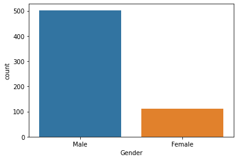

```python
# categorical attributes visualization
sns.countplot(df['Gender'])
```

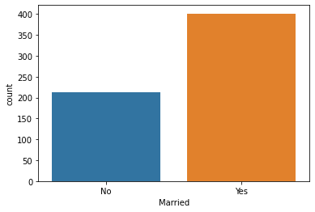

```python
sns.countplot(df['Married'])
```

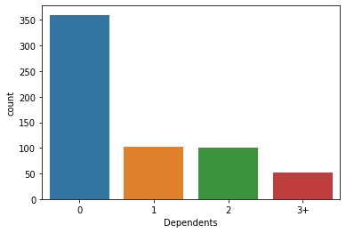

```python
sns.countplot(df['Dependents'])
```

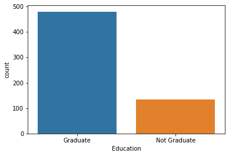

```python
sns.countplot(df['Education'])
```

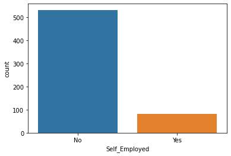

```python
sns.countplot(df['Self_Employed'])
```

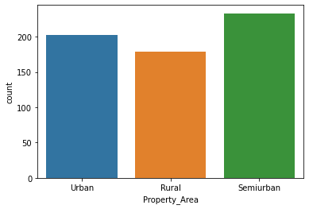

```python
sns.countplot(df['Property_Area'])
```

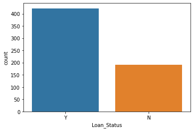

```python
sns.countplot(df['Loan_Status'])
```

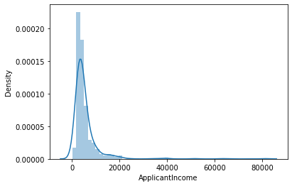

```python
# numerical attributes visualization
sns.distplot(df["ApplicantIncome"])
```

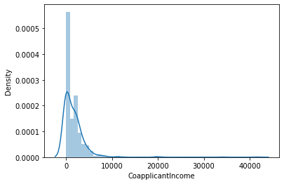

```python
sns.distplot(df["CoapplicantIncome"])
```

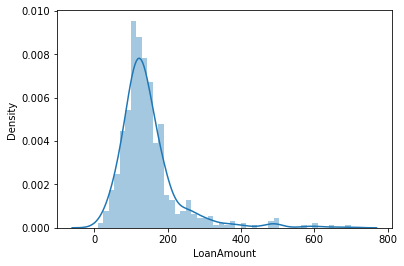

```python
sns.distplot(df["LoanAmount"])
```

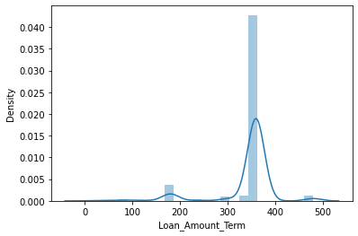

```python
sns.distplot(df['Loan_Amount_Term'])
```

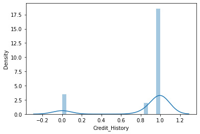

```python
sns.distplot(df['Credit_History'])
```

## Creation of new attributes

```python
# total income
df['Total_Income'] = df['ApplicantIncome'] + df['CoapplicantIncome']
df.head()
```

|  | Loan_ID | Gender | Married | Dependents | Education | Self_Employed | ApplicantIncome | CoapplicantIncome | LoanAmount | Loan_Amount_Term | Credit_History | Property_Area | Loan_Status | Total_Income |
| --- | --- | --- | --- | --- | --- | --- | --- | --- | --- | --- | --- | --- | --- | --- |
| 0 | LP001002 | Male | No | 0 | Graduate | No | 5849 | 0.0 | 146.412162 | 360.0 | 1.0 | Urban | Y | 5849.0 |
| 1 | LP001003 | Male | Yes | 1 | Graduate | No | 4583 | 1508.0 | 128.000000 | 360.0 | 1.0 | Rural | N | 6091.0 |
| 2 | LP001005 | Male | Yes | 0 | Graduate | Yes | 3000 | 0.0 | 66.000000 | 360.0 | 1.0 | Urban | Y | 3000.0 |
| 3 | LP001006 | Male | Yes | 0 | Not Graduate | No | 2583 | 2358.0 | 120.000000 | 360.0 | 1.0 | Urban | Y | 4941.0 |
| 4 | LP001008 | Male | No | 0 | Graduate | No | 6000 | 0.0 | 141.000000 | 360.0 | 1.0 | Urban | Y | 6000.0 |

## Log Transformation

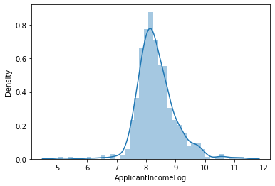

```python
# apply log transformation to the attribute
df['ApplicantIncomeLog'] = np.log(df['ApplicantIncome']+1)
sns.distplot(df["ApplicantIncomeLog"])
```

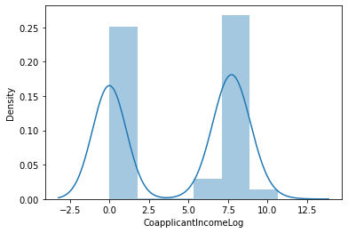

```python
df['CoapplicantIncomeLog'] = np.log(df['CoapplicantIncome']+1)
sns.distplot(df["CoapplicantIncomeLog"])
```

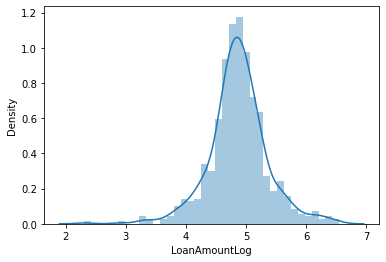

```python
df['LoanAmountLog'] = np.log(df['LoanAmount']+1)
sns.distplot(df["LoanAmountLog"])
```

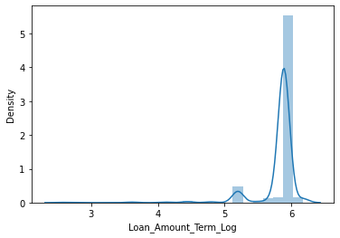

```python
df['Loan_Amount_Term_Log'] = np.log(df['Loan_Amount_Term']+1)
sns.distplot(df["Loan_Amount_Term_Log"])
```

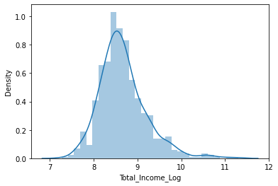

```python
df['Total_Income_Log'] = np.log(df['Total_Income']+1)
sns.distplot(df["Total_Income_Log"])
```

## Correlation Matrix

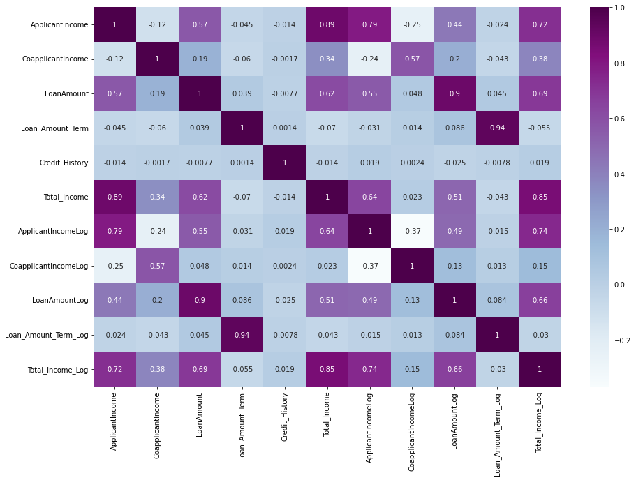

```python
corr = df.corr()
plt.figure(figsize=(15,10))
sns.heatmap(corr, annot = True, cmap="BuPu")
```

```python
df.head()
```

|  | Loan_ID | Gender | Married | Dependents | Education | Self_Employed | ApplicantIncome | CoapplicantIncome | LoanAmount | Loan_Amount_Term | Credit_History | Property_Area | Loan_Status | Total_Income | ApplicantIncomeLog | CoapplicantIncomeLog | LoanAmountLog | Loan_Amount_Term_Log | Total_Income_Log |
| --- | --- | --- | --- | --- | --- | --- | --- | --- | --- | --- | --- | --- | --- | --- | --- | --- | --- | --- | --- |
| 0 | LP001002 | Male | No | 0 | Graduate | No | 5849 | 0.0 | 146.412162 | 360.0 | 1.0 | Urban | Y | 5849.0 | 8.674197 | 0.000000 | 4.993232 | 5.888878 | 8.674197 |
| 1 | LP001003 | Male | Yes | 1 | Graduate | No | 4583 | 1508.0 | 128.000000 | 360.0 | 1.0 | Rural | N | 6091.0 | 8.430327 | 7.319202 | 4.859812 | 5.888878 | 8.714732 |
| 2 | LP001005 | Male | Yes | 0 | Graduate | Yes | 3000 | 0.0 | 66.000000 | 360.0 | 1.0 | Urban | Y | 3000.0 | 8.006701 | 0.000000 | 4.204693 | 5.888878 | 8.006701 |
| 3 | LP001006 | Male | Yes | 0 | Not Graduate | No | 2583 | 2358.0 | 120.000000 | 360.0 | 1.0 | Urban | Y | 4941.0 | 7.857094 | 7.765993 | 4.795791 | 5.888878 | 8.505525 |
| 4 | LP001008 | Male | No | 0 | Graduate | No | 6000 | 0.0 | 141.000000 | 360.0 | 1.0 | Urban | Y | 6000.0 | 8.699681 | 0.000000 | 4.955827 | 5.888878 | 8.699681 |

```python
# drop unnecessary columns
cols = ['ApplicantIncome', 'CoapplicantIncome', "LoanAmount", "Loan_Amount_Term", "Total_Income", 'Loan_ID', 'CoapplicantIncomeLog']
df = df.drop(columns=cols, axis=1)
df.head()
```

|  | Gender | Married | Dependents | Education | Self_Employed | Credit_History | Property_Area | Loan_Status | ApplicantIncomeLog | LoanAmountLog | Loan_Amount_Term_Log | Total_Income_Log |
| --- | --- | --- | --- | --- | --- | --- | --- | --- | --- | --- | --- | --- |
| 0 | Male | No | 0 | Graduate | No | 1.0 | Urban | Y | 8.674197 | 4.993232 | 5.888878 | 8.674197 |
| 1 | Male | Yes | 1 | Graduate | No | 1.0 | Rural | N | 8.430327 | 4.859812 | 5.888878 | 8.714732 |
| 2 | Male | Yes | 0 | Graduate | Yes | 1.0 | Urban | Y | 8.006701 | 4.204693 | 5.888878 | 8.006701 |
| 3 | Male | Yes | 0 | Not Graduate | No | 1.0 | Urban | Y | 7.857094 | 4.795791 | 5.888878 | 8.505525 |
| 4 | Male | No | 0 | Graduate | No | 1.0 | Urban | Y | 8.699681 | 4.955827 | 5.888878 | 8.699681 |

## Label Encoding

```python
from sklearn.preprocessing import LabelEncoder
cols = ['Gender',"Married","Education",'Self_Employed',"Property_Area","Loan_Status","Dependents"]
le = LabelEncoder()
for col in cols:
    df[col] = le.fit_transform(df[col])
```

```python
df.head()
```

|  | Gender | Married | Dependents | Education | Self_Employed | Credit_History | Property_Area | Loan_Status | ApplicantIncomeLog | LoanAmountLog | Loan_Amount_Term_Log | Total_Income_Log |
| --- | --- | --- | --- | --- | --- | --- | --- | --- | --- | --- | --- | --- |
| 0 | 1 | 0 | 0 | 0 | 0 | 1.0 | 2 | 1 | 8.674197 | 4.993232 | 5.888878 | 8.674197 |
| 1 | 1 | 1 | 1 | 0 | 0 | 1.0 | 0 | 0 | 8.430327 | 4.859812 | 5.888878 | 8.714732 |
| 2 | 1 | 1 | 0 | 0 | 1 | 1.0 | 2 | 1 | 8.006701 | 4.204693 | 5.888878 | 8.006701 |
| 3 | 1 | 1 | 0 | 1 | 0 | 1.0 | 2 | 1 | 7.857094 | 4.795791 | 5.888878 | 8.505525 |
| 4 | 1 | 0 | 0 | 0 | 0 | 1.0 | 2 | 1 | 8.699681 | 4.955827 | 5.888878 | 8.699681 |

```python
import warnings
warnings.filterwarnings('ignore')
```

## Train-Test Split

```python
# specify input and output attributes
X = df.drop(columns=['Loan_Status'], axis=1)
y = df['Loan_Status']
```

```python
from sklearn.model_selection import train_test_split
from sklearn.metrics import plot_confusion_matrix
from sklearn.metrics import plot_confusion_matrix
from sklearn.metrics import accuracy_score
from sklearn.metrics import precision_score
from sklearn.metrics import recall_score

x_train, x_test, y_train, y_test = train_test_split(X, y, test_size=0.2, random_state=42)

x_train_norm = (x_train - x_train.mean())/(x_train.max() - x_train.min())
x_test_norm = (x_test - x_test.mean())/(x_test.max() - x_test.min())
```

## Model Training

```python
# classify function
from sklearn.model_selection import cross_val_score
def classify(clf, x, y):
    x_train, x_test, y_train, y_test = train_test_split(X, y, test_size=0.2, random_state=42)
    clf.fit(x_train, y_train)
    print("Accuracy is", clf.score(x_test, y_test)*100)
    # cross validation - it is used for better validation of model
    # eg: cv-5, train-4, test-1
    score = cross_val_score(clf, x, y, cv=5)
    print("Cross validation is",np.mean(score)*100)
```

```python
from sklearn.linear_model import LogisticRegression
clf = LogisticRegression()
classify(clf, X, y)
```

```
Accuracy is 78.86178861788618
Cross validation is 80.9462881514061
```

```python
from sklearn.tree import DecisionTreeClassifier
clf = DecisionTreeClassifier()
classify(clf, X, y)
```

```
Accuracy is 68.29268292682927
Cross validation is 72.31507397041183
```

```python
from sklearn.ensemble import RandomForestClassifier,ExtraTreesClassifier
clf = RandomForestClassifier()
classify(clf, X, y)
```

```
Accuracy is 78.04878048780488
Cross validation is 78.50459816073571
```

```python
clf = ExtraTreesClassifier()
classify(clf, X, y)
```

```
Accuracy is 72.35772357723577
Cross validation is 77.20378515260562
```

```python
from sklearn.svm import SVC
clf = SVC()
classify(clf, X, y)
```

```
Accuracy is 65.04065040650406
Cross validation is 69.70545115287219
```

```python
from xgboost import XGBClassifier
clf = XGBClassifier(eval_metric='mlogloss')
classify(clf, X, y)
```

```
Accuracy is 74.79674796747967
Cross validation is 75.5631080900973
```

## Feature Engineering

### Univariate Feature Selection and XGBoost

```python
from sklearn.feature_selection import SelectKBest
from sklearn.feature_selection import chi2

select_feature = SelectKBest(chi2, k=11).fit(x_train, y_train)

print('Score List: ', select_feature.scores_)
print('Feature List: ', x_train.columns)
```

```
Score List:  [7.19500797e-03 2.06871125e+00 7.71256305e-01 1.52247417e+00
 7.78194275e-03 2.03768514e+01 1.11421163e-01 4.03909601e-03
 4.53042155e-02 8.22114016e-04 2.97424549e-03]
Feature List:  Index(['Gender', 'Married', 'Dependents', 'Education', 'Self_Employed',
       'Credit_History', 'Property_Area', 'ApplicantIncomeLog',
       'LoanAmountLog', 'Loan_Amount_Term_Log', 'Total_Income_Log'],
      dtype='object')
```

```python
x_train_2 = select_feature.transform(x_train)
x_test_2 = select_feature.transform(x_test)

clf = XGBClassifier(eval_metric='mlogloss').fit(x_train_2, y_train)

print("Accuracy is", clf.score(x_test, y_test)*100)
score = cross_val_score(clf, X, y, cv=5)
print("Cross validation is",np.mean(score)*100)
```

```
Accuracy is 74.79674796747967
Cross validation is 75.5631080900973
```

### Recursive Feature Elimination with Cross-Validation

```python
from sklearn.feature_selection import RFECV

clf = XGBClassifier(eval_metric='mlogloss')
rfecv = RFECV(estimator=clf, step=1, cv=5, scoring='accuracy', n_jobs=1).fit(x_train, y_train)

print('Optimal number of features: ', rfecv.n_features_)
print('Best features: ', x_train.columns[rfecv.support_])
```

```
Optimal number of features:  1
Best features:  Index(['Credit_History'], dtype='object')
```

```python
print('Accuracy is: ', accuracy_score(y_test, rfecv.predict(x_test)))
```

```
Accuracy is:  0.7886178861788617
```

```
[Text(0.5, 0, 'No. of selected features'), Text(0, 0.5, 'CV scores')]
```

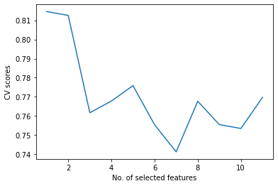

```python
num_features = [i for i in range(1,(rfecv.grid_scores_.shape[0]+1))]
cv_scores = [np.mean(score) for score in rfecv.grid_scores_]
ax = sns.lineplot(x=num_features, y=cv_scores)
ax.set(xlabel='No. of selected features', ylabel='CV scores')
```

### Principal Component Analysis

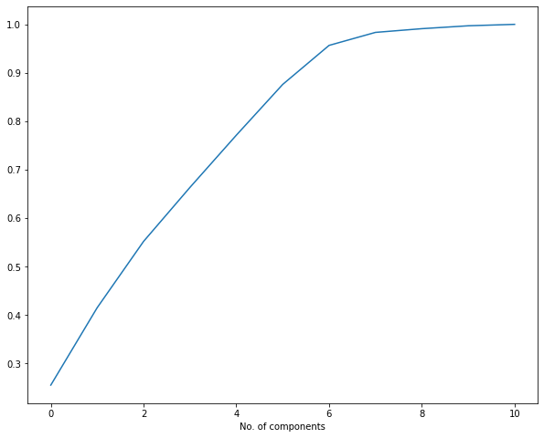

```python
from sklearn.decomposition import PCA

pca = PCA()
pca.fit(x_train_norm)

plt.figure(1, figsize=(10,8))
sns.lineplot(data=np.cumsum(pca.explained_variance_ratio_))
plt.xlabel('No. of components')
```

```python
x_best = x_train[x_train.columns[rfecv.support_]]
```

## Hyperparameter tuning

```python
from sklearn.model_selection import train_test_split
from sklearn.model_selection import KFold
from sklearn.model_selection import cross_val_score
from sklearn.model_selection import learning_curve
from sklearn.model_selection import GridSearchCV

from sklearn.metrics import plot_confusion_matrix
from sklearn.metrics import plot_confusion_matrix
from sklearn.metrics import accuracy_score
from sklearn.metrics import precision_score
from sklearn.metrics import recall_score

k_fold = KFold(n_splits=5, shuffle = True)
```

```python
# Logistic Regression
clf = GridSearchCV(LogisticRegression(),{
    'penalty':['l1', 'l2', 'elasticnet', 'none'],
    'C':[1,10,20],
    'solver':['newton-cg', 'lbfgs', 'liblinear', 'sag', 'saga']
} ,cv=k_fold)

clf.fit(x_best,y_train)
train_sizes, train_scores, test_scores, fit_times, score_times = learning_curve(clf, x_best,y_train, cv=k_fold,return_times=True)

LR = pd.DataFrame(clf.cv_results_)
LR.sort_values(by='rank_test_score').head()
```

|  | mean_fit_time | std_fit_time | mean_score_time | std_score_time | param_C | param_penalty | param_solver | params | split0_test_score | split1_test_score | split2_test_score | split3_test_score | split4_test_score | mean_test_score | std_test_score | rank_test_score |
| --- | --- | --- | --- | --- | --- | --- | --- | --- | --- | --- | --- | --- | --- | --- | --- | --- |
| 29 | 0.000867 | 0.000034 | 0.000336 | 0.000008 | 10 | l2 | saga | {'C': 10, 'penalty': 'l2', 'solver': 'saga'} | 0.818182 | 0.744898 | 0.877551 | 0.826531 | 0.806122 | 0.814657 | 0.04254 | 1 |
| 25 | 0.001275 | 0.000048 | 0.000350 | 0.000006 | 10 | l2 | newton-cg | {'C': 10, 'penalty': 'l2', 'solver': 'newton-cg'} | 0.818182 | 0.744898 | 0.877551 | 0.826531 | 0.806122 | 0.814657 | 0.04254 | 1 |
| 26 | 0.001283 | 0.000042 | 0.000356 | 0.000007 | 10 | l2 | lbfgs | {'C': 10, 'penalty': 'l2', 'solver': 'lbfgs'} | 0.818182 | 0.744898 | 0.877551 | 0.826531 | 0.806122 | 0.814657 | 0.04254 | 1 |
| 27 | 0.000557 | 0.000016 | 0.000330 | 0.000005 | 10 | l2 | liblinear | {'C': 10, 'penalty': 'l2', 'solver': 'liblinear'} | 0.818182 | 0.744898 | 0.877551 | 0.826531 | 0.806122 | 0.814657 | 0.04254 | 1 |
| 28 | 0.001012 | 0.000038 | 0.000335 | 0.000003 | 10 | l2 | sag | {'C': 10, 'penalty': 'l2', 'solver': 'sag'} | 0.818182 | 0.744898 | 0.877551 | 0.826531 | 0.806122 | 0.814657 | 0.04254 | 1 |

```python
# logistic regression score
estimator = LogisticRegression(C=10, penalty='l2',solver='liblinear')

train_sizes, train_scores, test_scores, fit_times, _ = learning_curve(estimator, x_best, y_train, cv=5,return_times=True)

plt.plot(train_sizes,np.mean(train_scores,axis=1))
plt.plot(train_sizes,np.mean(test_scores,axis=1))
```

[output not shown]

```python
# Decision Tree
clf = GridSearchCV(DecisionTreeClassifier(),{
    'criterion':['gini', 'entropy', 'log_loss'],
    'splitter':['best','random'],
    'max_features':['sqrt', 'log2', None]
} ,cv=k_fold)

clf.fit(x_best,y_train)
train_sizes, train_scores, test_scores, fit_times, score_times = learning_curve(clf, x_best, y_train, cv=k_fold,return_times=True)

DT = pd.DataFrame(clf.cv_results_)
DT.sort_values(by='rank_test_score').head()
```

|  | mean_fit_time | std_fit_time | mean_score_time | std_score_time | param_criterion | param_max_features | param_splitter | params | split0_test_score | split1_test_score | split2_test_score | split3_test_score | split4_test_score | mean_test_score | std_test_score | rank_test_score |
| --- | --- | --- | --- | --- | --- | --- | --- | --- | --- | --- | --- | --- | --- | --- | --- | --- |
| 0 | 0.000743 | 0.000271 | 0.000542 | 0.000157 | gini | sqrt | best | {'criterion': 'gini', 'max_features': 'sqrt', ... | 0.838384 | 0.77551 | 0.867347 | 0.816327 | 0.77551 | 0.814616 | 0.035796 | 1 |
| 11 | 0.000461 | 0.000030 | 0.000328 | 0.000006 | entropy | None | random | {'criterion': 'entropy', 'max_features': None,... | 0.838384 | 0.77551 | 0.867347 | 0.816327 | 0.77551 | 0.814616 | 0.035796 | 1 |
| 10 | 0.000450 | 0.000006 | 0.000323 | 0.000001 | entropy | None | best | {'criterion': 'entropy', 'max_features': None,... | 0.838384 | 0.77551 | 0.867347 | 0.816327 | 0.77551 | 0.814616 | 0.035796 | 1 |
| 9 | 0.000458 | 0.000007 | 0.000333 | 0.000004 | entropy | log2 | random | {'criterion': 'entropy', 'max_features': 'log2... | 0.838384 | 0.77551 | 0.867347 | 0.816327 | 0.77551 | 0.814616 | 0.035796 | 1 |
| 7 | 0.000457 | 0.000007 | 0.000335 | 0.000001 | entropy | sqrt | random | {'criterion': 'entropy', 'max_features': 'sqrt... | 0.838384 | 0.77551 | 0.867347 | 0.816327 | 0.77551 | 0.814616 | 0.035796 | 1 |

#### Decision Tree Learning Curve

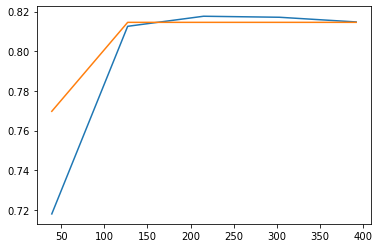

```python
# decision tree score
estimator = DecisionTreeClassifier(criterion='entropy', max_features='sqrt',splitter='best')

train_sizes, train_scores, test_scores, fit_times, _ = learning_curve(estimator, x_best, y_train, cv=5,return_times=True)

plt.plot(train_sizes,np.mean(train_scores,axis=1))
plt.plot(train_sizes,np.mean(test_scores,axis=1))
```

```python
# Random Forest
clf = GridSearchCV(RandomForestClassifier(),{
    'n_estimators':[10,60,100],
    'criterion':['gini', 'entropy', 'log_loss'],
    'max_features':['sqrt', 'log2', None]
} ,cv=k_fold)

clf.fit(x_best,y_train)
train_sizes, train_scores, test_scores, fit_times, score_times = learning_curve(clf, x_best, y_train, cv=k_fold,return_times=True)

RF = pd.DataFrame(clf.cv_results_)
RF.sort_values(by='rank_test_score').head()
```

|  | mean_fit_time | std_fit_time | mean_score_time | std_score_time | param_criterion | param_max_features | param_n_estimators | params | split0_test_score | split1_test_score | split2_test_score | split3_test_score | split4_test_score | mean_test_score | std_test_score | rank_test_score |
| --- | --- | --- | --- | --- | --- | --- | --- | --- | --- | --- | --- | --- | --- | --- | --- | --- |
| 0 | 0.005674 | 0.001162 | 0.000911 | 0.000116 | gini | sqrt | 10 | {'criterion': 'gini', 'max_features': 'sqrt', ... | 0.79798 | 0.846939 | 0.806122 | 0.826531 | 0.795918 | 0.814698 | 0.019417 | 1 |
| 17 | 0.038177 | 0.000060 | 0.002952 | 0.000022 | entropy | None | 100 | {'criterion': 'entropy', 'max_features': None,... | 0.79798 | 0.846939 | 0.806122 | 0.826531 | 0.795918 | 0.814698 | 0.019417 | 1 |
| 16 | 0.023206 | 0.000079 | 0.001944 | 0.000003 | entropy | None | 60 | {'criterion': 'entropy', 'max_features': None,... | 0.79798 | 0.846939 | 0.806122 | 0.826531 | 0.795918 | 0.814698 | 0.019417 | 1 |
| 15 | 0.004446 | 0.000129 | 0.000707 | 0.000008 | entropy | None | 10 | {'criterion': 'entropy', 'max_features': None,... | 0.79798 | 0.846939 | 0.806122 | 0.826531 | 0.795918 | 0.814698 | 0.019417 | 1 |
| 14 | 0.039015 | 0.000137 | 0.003074 | 0.000112 | entropy | log2 | 100 | {'criterion': 'entropy', 'max_features': 'log2... | 0.79798 | 0.846939 | 0.806122 | 0.826531 | 0.795918 | 0.814698 | 0.019417 | 1 |

#### Random Forest Learning Curve

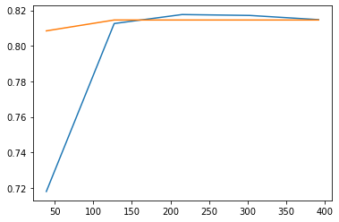

```python
# random forest score
estimator = RandomForestClassifier(n_estimators=60,criterion='gini', max_features='log2')

train_sizes, train_scores, test_scores, fit_times, _ = learning_curve(estimator, x_best, y_train, cv=5,return_times=True)

plt.plot(train_sizes,np.mean(train_scores,axis=1))
plt.plot(train_sizes,np.mean(test_scores,axis=1))
```

```python
# Extra Trees
clf = GridSearchCV(ExtraTreesClassifier(),{
    'n_estimators':[10,60,100],
    'criterion':['gini', 'entropy', 'log_loss'],
    'max_features':['sqrt', 'log2', None]
} ,cv=k_fold)

clf.fit(x_best,y_train)
train_sizes, train_scores, test_scores, fit_times, score_times = learning_curve(clf, x_best, y_train, cv=k_fold,return_times=True)

RF = pd.DataFrame(clf.cv_results_)
RF.sort_values(by='rank_test_score').head()
```

|  | mean_fit_time | std_fit_time | mean_score_time | std_score_time | param_criterion | param_max_features | param_n_estimators | params | split0_test_score | split1_test_score | split2_test_score | split3_test_score | split4_test_score | mean_test_score | std_test_score | rank_test_score |
| --- | --- | --- | --- | --- | --- | --- | --- | --- | --- | --- | --- | --- | --- | --- | --- | --- |
| 0 | 0.004407 | 0.000581 | 0.000990 | 0.000117 | gini | sqrt | 10 | {'criterion': 'gini', 'max_features': 'sqrt', ... | 0.808081 | 0.826531 | 0.836735 | 0.77551 | 0.826531 | 0.814677 | 0.021657 | 1 |
| 17 | 0.028284 | 0.000431 | 0.003190 | 0.000118 | entropy | None | 100 | {'criterion': 'entropy', 'max_features': None,... | 0.808081 | 0.826531 | 0.836735 | 0.77551 | 0.826531 | 0.814677 | 0.021657 | 1 |
| 16 | 0.017020 | 0.000095 | 0.001989 | 0.000013 | entropy | None | 60 | {'criterion': 'entropy', 'max_features': None,... | 0.808081 | 0.826531 | 0.836735 | 0.77551 | 0.826531 | 0.814677 | 0.021657 | 1 |
| 15 | 0.003338 | 0.000004 | 0.000720 | 0.000037 | entropy | None | 10 | {'criterion': 'entropy', 'max_features': None,... | 0.808081 | 0.826531 | 0.836735 | 0.77551 | 0.826531 | 0.814677 | 0.021657 | 1 |
| 14 | 0.028078 | 0.000053 | 0.002999 | 0.000004 | entropy | log2 | 100 | {'criterion': 'entropy', 'max_features': 'log2... | 0.808081 | 0.826531 | 0.836735 | 0.77551 | 0.826531 | 0.814677 | 0.021657 | 1 |

#### Extra Trees Learning Curve

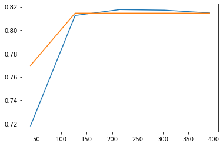

```python
# extra trees score
estimator = ExtraTreesClassifier(n_estimators=60,criterion='entropy', max_features='log2')

train_sizes, train_scores, test_scores, fit_times, _ = learning_curve(estimator, x_best, y_train, cv=5,return_times=True)

plt.plot(train_sizes,np.mean(train_scores,axis=1))
plt.plot(train_sizes,np.mean(test_scores,axis=1))
```

```python
# SVM
clf = GridSearchCV(SVC(),{
    'C':[1,10,20],
    'kernel':['linear', 'poly', 'rbf', 'sigmoid'],
    'degree':[2,3,4]
    # 'gamma':['auto', 'scale'],
    # 'coef0':[0,1,2,3],
    # 'shrinking':['True','False'],
    # 'probability':['True','False'],
    # 'class_weight':['balanced'],
    # 'max_iter':[-1],
    # 'random_state':[42]
} ,cv=k_fold)

clf.fit(x_best,y_train)
train_sizes, train_scores, test_scores, fit_times, score_times = learning_curve(clf, x_best, y_train, cv=k_fold,return_times=True)

SVM = pd.DataFrame(clf.cv_results_)
SVM.sort_values(by='rank_test_score').head()
```

|  | mean_fit_time | std_fit_time | mean_score_time | std_score_time | param_C | param_degree | param_kernel | params | split0_test_score | split1_test_score | split2_test_score | split3_test_score | split4_test_score | mean_test_score | std_test_score | rank_test_score |
| --- | --- | --- | --- | --- | --- | --- | --- | --- | --- | --- | --- | --- | --- | --- | --- | --- |
| 0 | 0.001592 | 0.000252 | 0.000721 | 0.000096 | 1 | 2 | linear | {'C': 1, 'degree': 2, 'kernel': 'linear'} | 0.828283 | 0.77551 | 0.867347 | 0.77551 | 0.826531 | 0.814636 | 0.035122 | 1 |
| 32 | 0.001195 | 0.000029 | 0.000488 | 0.000008 | 20 | 4 | linear | {'C': 20, 'degree': 4, 'kernel': 'linear'} | 0.828283 | 0.77551 | 0.867347 | 0.77551 | 0.826531 | 0.814636 | 0.035122 | 1 |
| 31 | 0.001596 | 0.000043 | 0.000570 | 0.000011 | 20 | 3 | sigmoid | {'C': 20, 'degree': 3, 'kernel': 'sigmoid'} | 0.828283 | 0.77551 | 0.867347 | 0.77551 | 0.826531 | 0.814636 | 0.035122 | 1 |
| 30 | 0.001317 | 0.000038 | 0.000863 | 0.000026 | 20 | 3 | rbf | {'C': 20, 'degree': 3, 'kernel': 'rbf'} | 0.828283 | 0.77551 | 0.867347 | 0.77551 | 0.826531 | 0.814636 | 0.035122 | 1 |
| 29 | 0.025659 | 0.002409 | 0.000513 | 0.000009 | 20 | 3 | poly | {'C': 20, 'degree': 3, 'kernel': 'poly'} | 0.828283 | 0.77551 | 0.867347 | 0.77551 | 0.826531 | 0.814636 | 0.035122 | 1 |

```python
# svm score
estimator = SVC(C=1,degree=2, kernel='linear')

train_sizes, train_scores, test_scores, fit_times, _ = learning_curve(estimator, x_best, y_train, cv=5,return_times=True)

plt.plot(train_sizes,np.mean(train_scores,axis=1))
plt.plot(train_sizes,np.mean(test_scores,axis=1))
```

[output not shown]

```python
# XGBClassifier
clf = GridSearchCV(XGBClassifier(),{
    'n_estimators':[1,10,20],
    'booster':['gbtree', 'gblinear', 'dart'],
    'eval_metric':['mlogloss']
} ,cv=k_fold)

clf.fit(x_best,y_train)
train_sizes, train_scores, test_scores, fit_times, score_times = learning_curve(clf, x_best, y_train, cv=k_fold,return_times=True)

XGB = pd.DataFrame(clf.cv_results_)
XGB.sort_values(by='rank_test_score').head()
```

|  | mean_fit_time | std_fit_time | mean_score_time | std_score_time | param_booster | param_eval_metric | param_n_estimators | params | split0_test_score | split1_test_score | split2_test_score | split3_test_score | split4_test_score | mean_test_score | std_test_score | rank_test_score |
| --- | --- | --- | --- | --- | --- | --- | --- | --- | --- | --- | --- | --- | --- | --- | --- | --- |
| 0 | 0.003111 | 0.000685 | 0.002186 | 0.001226 | gbtree | mlogloss | 1 | {'booster': 'gbtree', 'eval_metric': 'mlogloss... | 0.79798 | 0.826531 | 0.816327 | 0.795918 | 0.836735 | 0.814698 | 0.015877 | 1 |
| 1 | 0.003099 | 0.001133 | 0.000854 | 0.000112 | gbtree | mlogloss | 10 | {'booster': 'gbtree', 'eval_metric': 'mlogloss... | 0.79798 | 0.826531 | 0.816327 | 0.795918 | 0.836735 | 0.814698 | 0.015877 | 1 |
| 2 | 0.006327 | 0.002770 | 0.000760 | 0.000013 | gbtree | mlogloss | 20 | {'booster': 'gbtree', 'eval_metric': 'mlogloss... | 0.79798 | 0.826531 | 0.816327 | 0.795918 | 0.836735 | 0.814698 | 0.015877 | 1 |
| 4 | 0.001549 | 0.000675 | 0.000705 | 0.000154 | gblinear | mlogloss | 10 | {'booster': 'gblinear', 'eval_metric': 'mloglo... | 0.79798 | 0.826531 | 0.816327 | 0.795918 | 0.836735 | 0.814698 | 0.015877 | 1 |
| 5 | 0.001426 | 0.000060 | 0.000594 | 0.000007 | gblinear | mlogloss | 20 | {'booster': 'gblinear', 'eval_metric': 'mloglo... | 0.79798 | 0.826531 | 0.816327 | 0.795918 | 0.836735 | 0.814698 | 0.015877 | 1 |

```python
# xgb score
estimator = XGBClassifier(booster='gblinear', n_estimators=10, eval_metric='mlogloss')

train_sizes, train_scores, test_scores, fit_times, _ = learning_curve(estimator, x_best, y_train, cv=5,return_times=True)

plt.plot(train_sizes,np.mean(train_scores,axis=1))
plt.plot(train_sizes,np.mean(test_scores,axis=1))
```

[output not shown]

## Confusion Matrix

A confusion matrix is a summary of prediction results on a classification problem. The number of correct and incorrect predictions are summarized with count values and broken down by each class. It gives us insight not only into the errors being made by a classifier but more importantly the types of errors that are being made.

```python
# logistic regression score
clf = LogisticRegression(C=10, penalty='l2',solver='liblinear')
clf.fit(x_best,y_train)
```

```
LogisticRegression(C=10, solver='liblinear')
```

```python
y_pred = clf.predict(x_test[['Credit_History']])
plot_confusion_matrix(clf, x_test[['Credit_History']], y_test)
```

[output not shown]

```
<sklearn.metrics._plot.confusion_matrix.ConfusionMatrixDisplay at 0x12669ad90>
```

```python
accuracy_score(y_test,y_pred)
```

```
0.7886178861788617
```

```python
precision_score(y_test,y_pred)
```

```
0.7596153846153846
```

```python
recall_score(y_test,y_pred)
```

```
0.9875
```

```python
# svm score
clf = SVC(C=1,degree=2, kernel='linear')
clf.fit(x_best,y_train)
```

```
SVC(C=1, degree=2, kernel='linear')
```

```python
y_pred = clf.predict(x_test[['Credit_History']])
plot_confusion_matrix(clf, x_test[['Credit_History']], y_test)
```

[output not shown]

```
<sklearn.metrics._plot.confusion_matrix.ConfusionMatrixDisplay at 0x12454d0d0>
```

```python
accuracy_score(y_test,y_pred)
```

```
0.7886178861788617
```

```python
precision_score(y_test,y_pred)
```

```
0.7596153846153846
```

```python
recall_score(y_test,y_pred)
```

```
0.9875
```

```python
# xgb score
clf = XGBClassifier(booster='gblinear', n_estimators=10, eval_metric='mlogloss')
clf.fit(x_best,y_train)
```

```
XGBClassifier(base_score=0.5, booster='gblinear', colsample_bylevel=None,
              colsample_bynode=None, colsample_bytree=None,
              enable_categorical=False, eval_metric='mlogloss', gamma=None,
              gpu_id=-1, importance_type=None, interaction_constraints=None,
              learning_rate=0.5, max_delta_step=None, max_depth=None,
              min_child_weight=None, missing=nan, monotone_constraints=None,
              n_estimators=10, n_jobs=8, num_parallel_tree=None, predictor=None,
              random_state=0, reg_alpha=0, reg_lambda=0, scale_pos_weight=1,
              subsample=None, tree_method=None, validate_parameters=1,
              verbosity=None)
```

```python
y_pred = clf.predict(x_test[['Credit_History']])
plot_confusion_matrix(clf, x_test[['Credit_History']], y_test)
```

[output not shown]

```
<sklearn.metrics._plot.confusion_matrix.ConfusionMatrixDisplay at 0x1267a2220>
```

```python
accuracy_score(y_test,y_pred)
```

```
0.7886178861788617
```

```python
precision_score(y_test,y_pred)
```

```
0.7596153846153846
```

```python
recall_score(y_test,y_pred)
```

```
0.9875
```

```python
from rfpimp import *   # pip install rfpimp

from sklearn import tree

import dtreeviz
from dtreeviz import clfviz
```

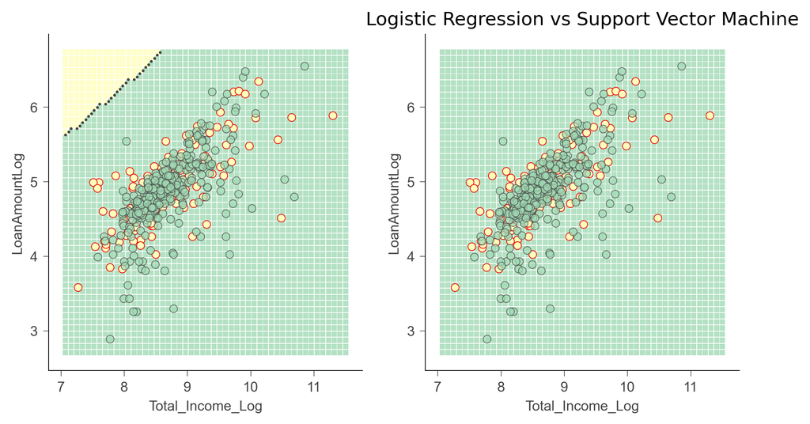

```python
X = x_train[['Total_Income_Log','LoanAmountLog']]
y = y_train

lr = LogisticRegression(C=10, penalty='l2',solver='liblinear')
lr.fit(X, y)

svm = SVC(C=1,degree=2, kernel='linear', probability=True)
svm.fit(X,y)


fig,axes = plt.subplots(1,2, figsize=(8,4), dpi=300)
clfviz(lr, X, y, ax=axes[0],
       # show classification regions not probabilities
       show=['instances', 'boundaries', 'misclassified'],
       feature_names=['Total_Income_Log','LoanAmountLog'], target_name='Loan_Status')
clfviz(svm, X, y, ax=axes[1],
       # show classification regions not probabilities
       show=['instances', 'boundaries', 'misclassified'],
       feature_names=['Total_Income_Log','LoanAmountLog'], target_name='Loan_Status')
plt.title(label='Logistic Regression vs Support Vector Machine')
plt.show()
```

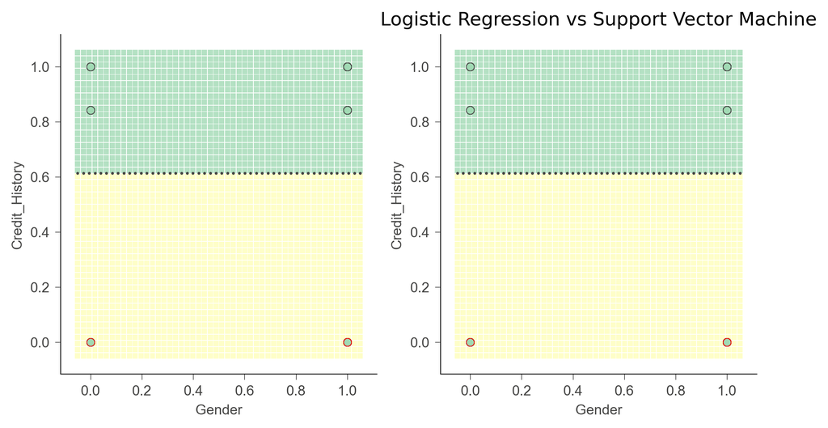

```python
X = x_train[['Gender','Credit_History']]
y = y_train

lr = LogisticRegression(C=10, penalty='l2',solver='liblinear')
lr.fit(X, y)

svm = SVC(C=1,degree=2, kernel='linear', probability=True)
svm.fit(X,y)


fig,axes = plt.subplots(1,2, figsize=(8,4), dpi=300)
clfviz(lr, X, y, ax=axes[0],
       # show classification regions not probabilities
       show=['instances', 'boundaries', 'misclassified'],
       feature_names=['Gender','Credit_History'], target_name='Loan_Status')
clfviz(svm, X, y, ax=axes[1],
       # show classification regions not probabilities
       show=['instances', 'boundaries', 'misclassified'],
       feature_names=['Gender','Credit_History'], target_name='Loan_Status')
plt.title(label='Logistic Regression vs Support Vector Machine')
plt.show()
```

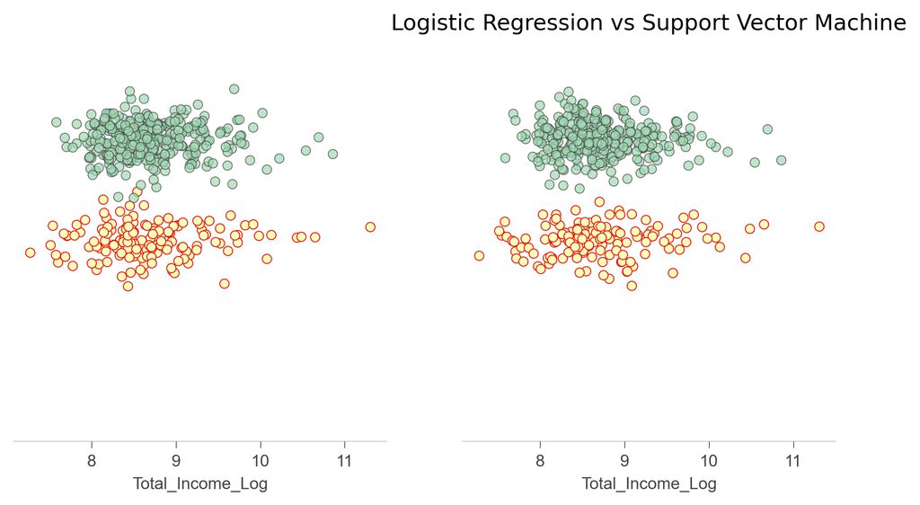

```python
X = x_train[['Total_Income_Log']]
y = y_train

lr = LogisticRegression(C=10, penalty='l2',solver='liblinear')
lr.fit(X, y)

svm = SVC(C=1,degree=2, kernel='linear', probability=True)
svm.fit(X,y)


fig,axes = plt.subplots(1,2, figsize=(8,4), dpi=300)
clfviz(lr, X, y, ax=axes[0],
       # show classification regions not probabilities
       show=['instances', 'boundaries', 'misclassified'],
       feature_names=['Total_Income_Log'], target_name='Loan_Status')
clfviz(svm, X, y, ax=axes[1],
       # show classification regions not probabilities
       show=['instances', 'boundaries', 'misclassified'],
       feature_names=['Total_Income_Log'], target_name='Loan_Status')
plt.title(label='Logistic Regression vs Support Vector Machine')
plt.show()
```

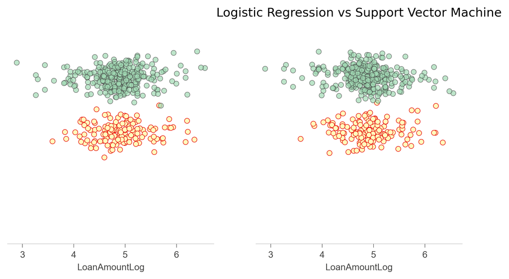

```python
X = x_train[['LoanAmountLog']]
y = y_train

lr = LogisticRegression(C=10, penalty='l2',solver='liblinear')
lr.fit(X, y)

svm = SVC(C=1,degree=2, kernel='linear', probability=True)
svm.fit(X,y)


fig,axes = plt.subplots(1,2, figsize=(8,4), dpi=300)
clfviz(lr, X, y, ax=axes[0],
       # show classification regions not probabilities
       show=['instances', 'boundaries', 'misclassified'],
       feature_names=['LoanAmountLog'], target_name='Loan_Status')
clfviz(svm, X, y, ax=axes[1],
       # show classification regions not probabilities
       show=['instances', 'boundaries', 'misclassified'],
       feature_names=['LoanAmountLog'], target_name='Loan_Status')
plt.title(label='Logistic Regression vs Support Vector Machine')
plt.show()
```

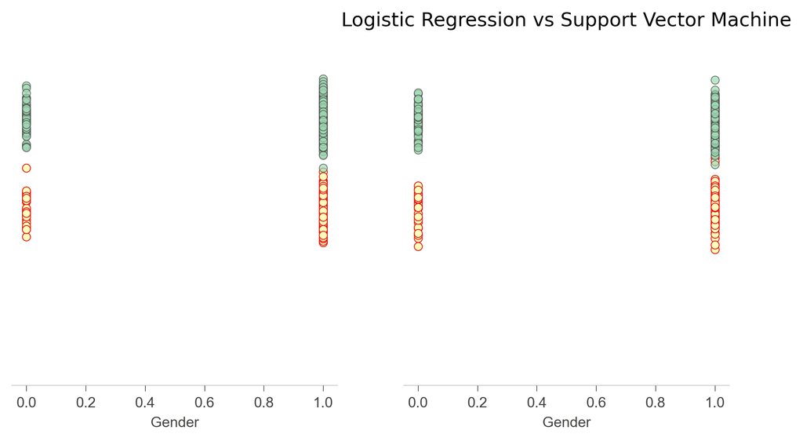

```python
X = x_train[['Gender']]
y = y_train

lr = LogisticRegression(C=10, penalty='l2',solver='liblinear')
lr.fit(X, y)

svm = SVC(C=1,degree=2, kernel='linear', probability=True)
svm.fit(X,y)


fig,axes = plt.subplots(1,2, figsize=(8,4), dpi=300)
clfviz(lr, X, y, ax=axes[0],
       # show classification regions not probabilities
       show=['instances', 'boundaries', 'misclassified'],
       feature_names=['Gender'], target_name='Loan_Status')
clfviz(svm, X, y, ax=axes[1],
       # show classification regions not probabilities
       show=['instances', 'boundaries', 'misclassified'],
       feature_names=['Gender'], target_name='Loan_Status')
plt.title(label='Logistic Regression vs Support Vector Machine')
plt.show()
```

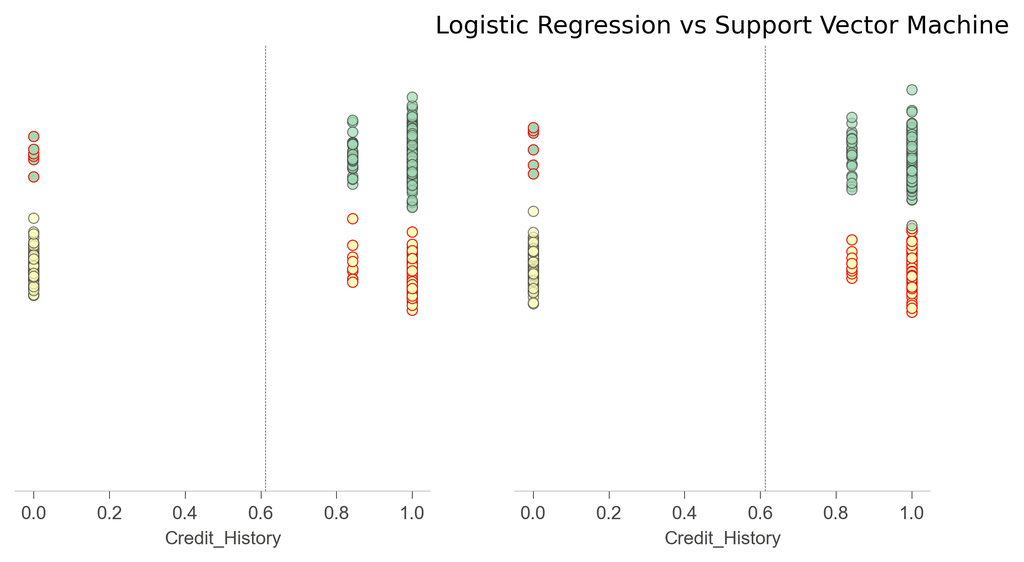

```python
X = x_train[['Credit_History']]
y = y_train

lr = LogisticRegression(C=10, penalty='l2',solver='liblinear')
lr.fit(X, y)

svm = SVC(C=1,degree=2, kernel='linear', probability=True)
svm.fit(X,y)


fig,axes = plt.subplots(1,2, figsize=(8,4), dpi=300)
clfviz(lr, X, y, ax=axes[0],
       # show classification regions not probabilities
       show=['instances', 'boundaries', 'misclassified'],
       feature_names=['Credit_History'], target_name='Loan_Status')
clfviz(svm, X, y, ax=axes[1],
       # show classification regions not probabilities
       show=['instances', 'boundaries', 'misclassified'],
       feature_names=['Credit_History'], target_name='Loan_Status')
plt.title(label='Logistic Regression vs Support Vector Machine')
plt.show()
```